# Example Stratigraphic Architecture

## Introduction

```r
library(StratPal)
```

This vignette provides an overview over the example stratigraphic architecture provided with the `StratPal` package.

## Stratigraphic Context

The example data is taken from a synthetic carbonate platform simulated using CarboKitten.jl (Hidding et al. 2025). It emulates scenario A from Hohmann et al (2024), which was originally simulated in CarboCAT (Burgess 2013), and is characterized by a sinusoidal sea level curve and 2 long (> 0.5 Myr) hiatuses over the 2 Myr duration of the run.

## Dataset structure

The structure of the dataset is explained on the help pages, which is available using

```r
?scenarioA
```

## Simulation settings

The full code to generate simulation data and visualizations is available [here](https://github.com/MindTheGap-ERC/StratPal_data_prep). The simulation was run over 2 Myr at steps of 1 kyr, with data extracted at 2, 4, 6, 8, 10, and 12 km from shore in the middle of the simulated platform. Three carbonate factories were used: euphotic, oligophotic, and aphotic:

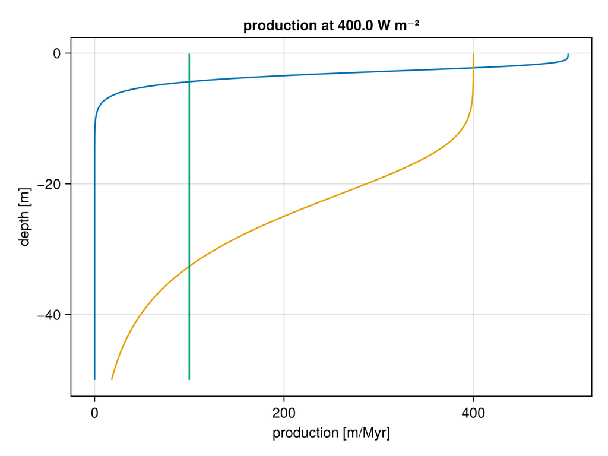

Production profile of the three carbonate factories

The eustatic sea level curve is a combination of third and fifth order changes with an amplitude of 20 and 2 m and a period of 1 and 0.112 Myr:

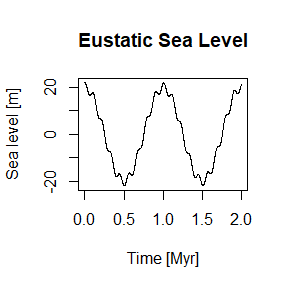

For users interested in more details, we recommend inspecting the simulation source code (written in Julia).

## Platform visualization

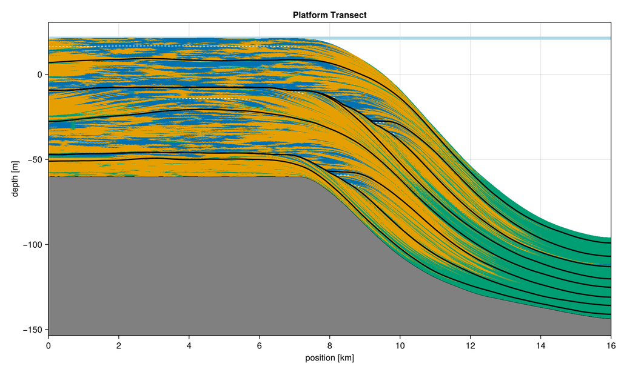

Transect through the carbonate platform. Black lines separate systems tracts.

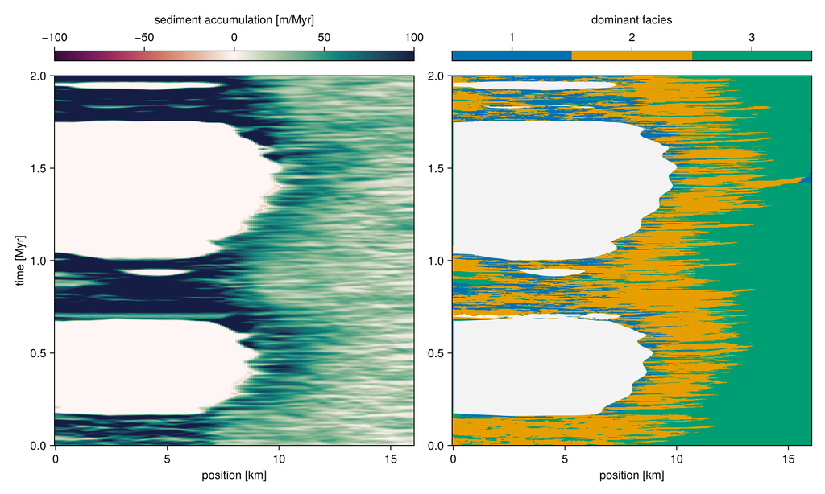

Wheeler diagram of the platform, showing both dominant facies and seidimentation rate.

## References

- Hidding, Johan, Jarochowska, Emilia, Hohmann, Niklas, Liu, Xianyi Burgess, Peter and Spreeuw, Hanno: “CarboKitten.jl – an open source toolkit for carbonate stratigraphic modeling.” Preprint. https://doi.org/10.5194/egusphere-2025-4561
- Burgess, Peter. 2013. “CarboCAT: A cellular automata model of heterogeneous carbonate strata.” Computers & Geosciences. https://doi.org/10.1016/j.cageo.2011.08.026.
- Hohmann, Niklas; Koelewijn, Joël R.; Burgess, Peter; Jarochowska, Emilia. 2024. “Identification of the mode of evolution in incomplete carbonate successions.” BMC Ecology and Evolution 24, 113. https://doi.org/10.1186/s12862-024-02287-2.